# Hamza_ALY6000FinalProject

Hamza Alshaibani

2023-02-26

## TITLE

**ALY600 INTRODUCTION TO ANALYTICS**  
**NORTHEASTERN UNIVERSITY**  
Hamza Alshaibani  
Date: “2023-02-26”

Final Project

| Library Data |
| --- |

```r
library(RColorBrewer)
library(plyr)
library(epiDisplay)
library(rmarkdown)
library(readxl)
library(readr)
library(knitr)
library(tidyverse)
library(dplyr)
library(kableExtra)
library(magrittr)
library(RColorBrewer)
library(kableExtra)
library(FSA)
m6data <- read_excel("Datasets/m6data.xlsx")
```

**Task1.1**  
In task1.1, I have decided to examine the frequency of each market. The reason I chose this specific method for looking at my dataset is that I will continue to examine the data in future tasks by categorizing them by market.

```r
#using the table, and kable_styling functions to examine Market frequency
MarketFreq <- table(m6data$Market)
MarketFreq1 <- MarketFreq %>%
  kbl(caption = "Frequency of Each Market") %>%
  kable_classic() %>%
  kable_material_dark() #(Zhu, 2021)
MarketFreq1
```

Frequency of Each Market

| Var1 | Freq |
| --- | --- |
| Africa | 62 |
| Asia Pacific | 302 |
| Europe | 261 |
| LATAM | 205 |
| USCA | 170 |

The table above shows that the market with the greatest frequency is Asia Pacific. This leads me to assume that it will consequently also have the highes sales, the highest total amount of losses, and the greatest quantity of products sold. Similarly, the Africa market will have the least of the variables mentioned.

**Task1.2**  
In task1.2, I have chosen to use a barplot as well as a pie chart to help visualize the market share of each market for a better understanding of the dataset.

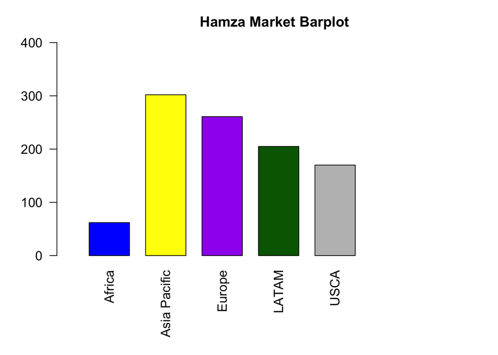

```r
#Using the par(mar) function, barplot() function, and pie() function to visualize market frequency.
par(mar = c(7,4,3,.4))
MarketBar <- barplot(MarketFreq,
        main = "Hamza Market Barplot",
        xlim = c(0, 10),
        ylim = c(0,400),
        las = 2,
        col = c("blue", "yellow", "purple", "darkgreen", "grey"),
        cex.axis = 1.1,
        cex.names = 1.1,
        space = 0.4)
text(MarketFreq,
     MarketBar,
     MarketFreq,
     cex = 0.7,
     pos = 3)
```

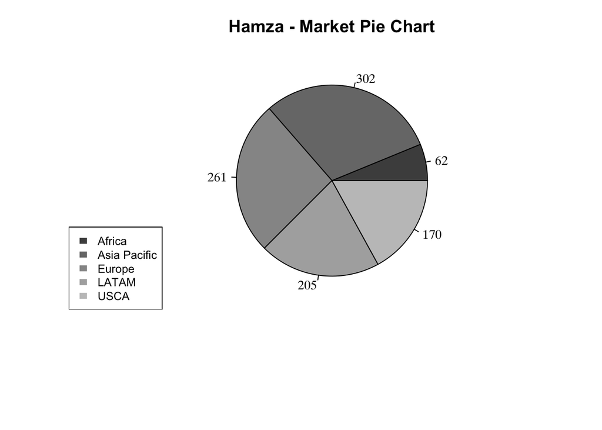

```r
MarketPie <- pie(MarketFreq,
                  main = "Hamza - Market Pie Chart",
                 col =  gray.colors(7),
                  labels = MarketFreq,
                  radius = 0.8,
                 lty = 1,
                 cex = 0.9,
                 font = 5)
legend("bottomleft",
       legend = paste(unique(sort(m6data$Market))),
       fill = gray.colors(7),
       border = "white",
         cex = 0.8) #(Chiluiza, 2021)
```

Based off of the table two graphs presented above, I can now better visualize the difference in each of the market shares of the 5 markets

**Task 2**  
Task 2 is a horizontal boxplot and histogram that shows the data distribution of the shipping cost of the items grouped onto one visual.

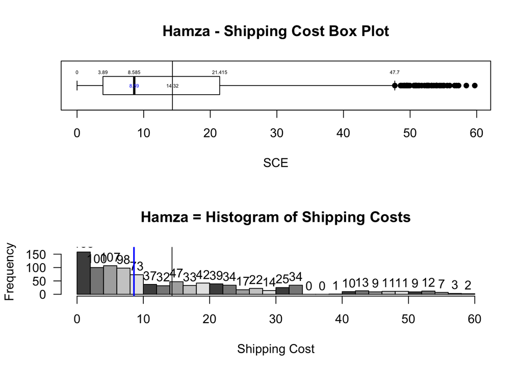

```r
#boxplot and histograms of shipping cost
par(mfcol=c(2,1))
boxplot(m6data$Shipping_Cost_Each,
horizontal = T,
main = "Hamza - Shipping Cost Box Plot",
col = brewer.pal(9, "Greys"),
xlab = "SCE",
whisklty = 1,
outpch = 16,
outcol = "black")
text(x = boxplot.stats(m6data$Shipping_Cost_Each)$stats,
     labels = boxplot.stats(m6data$Shipping_Cost_Each)$stats,
     y = 1.3,
     cex = 0.4,)
task2mean <- mean(m6data$Shipping_Cost_Each)
text(x = task2mean,
     labels = round(task2mean, 2),
     y = 1,
     cex = 0.4,
     col = "black") #(Chiluiza, 2021)

abline(v = mean(m6data$Shipping_Cost_Each),
       col = "black",
       lwd = 1)

task2median <- median(m6data$Shipping_Cost_Each)
text(x = task2median,
     labels = round(task2median, 2),
     y = 1,
     cex = 0.4,
     col = "blue")

hist(m6data$Shipping_Cost_Each,
     main = "Hamza = Histogram of Shipping Costs",
     las = 1,
     ylab = "Frequency",
     xlab = "Shipping Cost",
     breaks = 40,
     col = gray.colors(5),
     ylim = c(0,170),
     labels = T
     )

abline(v = mean(m6data$Shipping_Cost_Each),
       col = "black",
       lwd = 1)
abline(v = median(m6data$Shipping_Cost_Each),
       col = "blue",
       lwd = 2) #(Chiluiza, 2021)
```

**Task 3**  
Task 3 is a boxplot that displays the shipping cost by market.

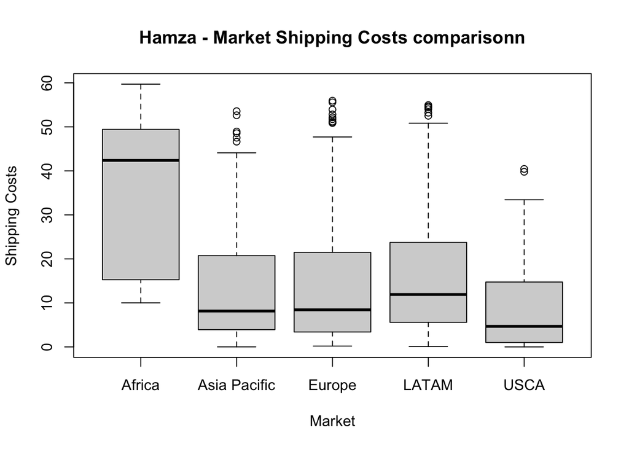

```r
#boxplot function to display the shipping cost by market
boxplot(m6data$Shipping_Cost_Each ~ m6data$Market,
         main = "Hamza - Market Shipping Costs comparisonn",
         ylab = "Shipping Costs",
         xlab = "Market") #(Chiluiza, 2021)
```

Based off of the visual displayed above, it is apparent that Africa’s shipping costs are fairly distributed with no outliers, while also contaning the highest max and minimum shipping costs. Based off of the visual, I would be more inclined to want to ship to the USCA market as it contains the overal lowest shipping costs with minimal outliers. This further gives insight as to why the Africa market had the least frequency compared to the rest.

**Task 4**  
Task 4 is a table and barplot that display the mean shipping costs per market.

```r
#Using a barplot and table to display mean shipping costs per market.
market_mean_sc <- tapply(m6data$Shipping_Cost_Each, m6data$Market, mean, no.rm=T)
market_mean_sc1 <- market_mean_sc %>%
  kbl(caption = "Mean Shipping Cost of Each Market") %>%
  kable_classic() %>%
  kable_material_dark() #(Zhu, 2021)
market_mean_sc1
```

Mean Shipping Cost of Each Market

|  | x |
| --- | --- |
| Africa | 32.815323 |
| Asia Pacific | 13.019669 |
| Europe | 13.820000 |
| LATAM | 16.467902 |
| USCA | 8.090235 |

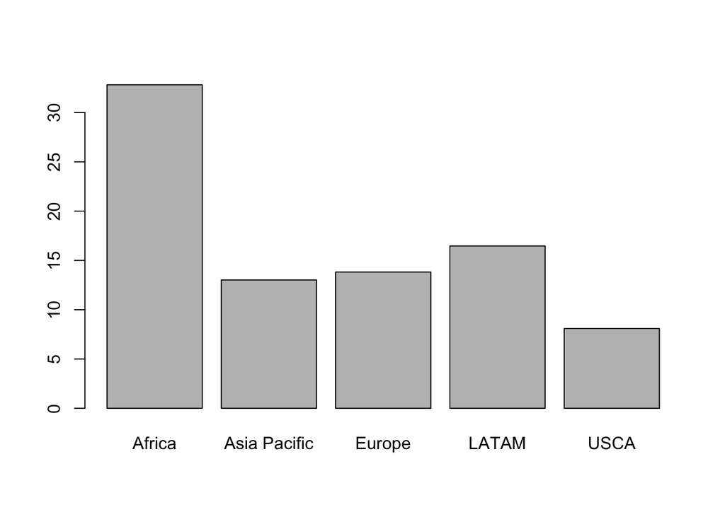

```r
barplot(market_mean_sc)
```

In this table, you can see that the mean shipping cost per market is displayed. The results are expected as they directly relate to the boxplots above, showing the Africa market with the greatest mean, and the USCA market with the lowest.  
For extra credit…

```r
#Using barplot() to display median quantities of each market to see if there is a relationship with their frequency
market_median_sc <- tapply(m6data$Quantity, m6data$Market, median, no.rm=T) #(Chiluiza, 2021)
market_median_sc1 <- market_median_sc %>%
  kbl(caption = "Median Quantity of Each Market") %>%
  kable_classic() %>%
  kable_material_dark() #(Zhu, 2021)
market_median_sc1
```

Median Quantity of Each Market

|  | x |
| --- | --- |
| Africa | 127 |
| Asia Pacific | 128 |
| Europe | 137 |
| LATAM | 101 |
| USCA | 244 |

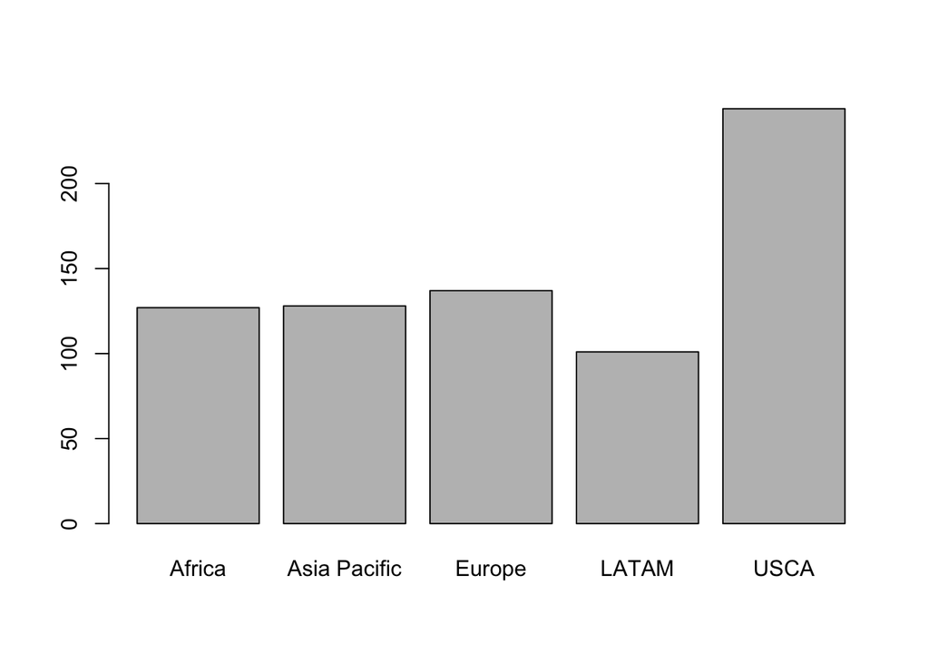

```r
barplot(market_median_sc)
```

Based off of the table barplot, It is interesting to see that though USCA has the greatest median in quantity, it also has the second-to-least frequency amongst its competing markets.

**Task 5**  
Task 5 is a boxplot comparing the shipping cost distribution based on each shipping mode.

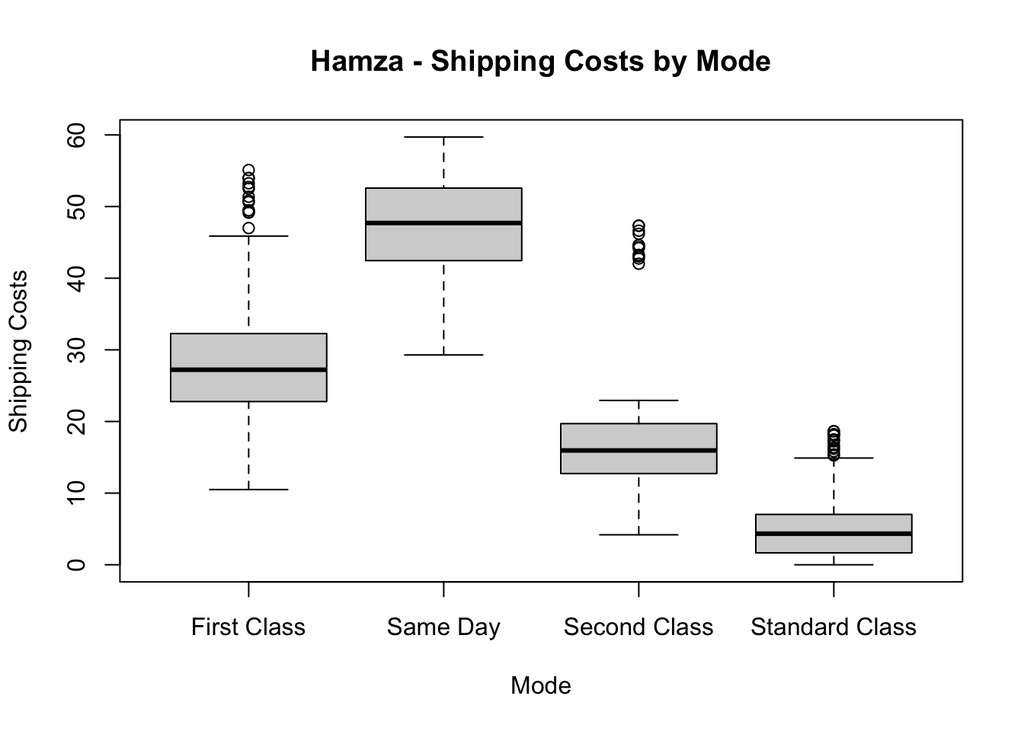

```r
#Using boxplot to compare shipping costs by shipping mode.
boxplot(m6data$Shipping_Cost_Each ~ m6data$ShipMode,
         main = "Hamza - Shipping Costs by Mode",
         ylab = "Shipping Costs",
         xlab = "Mode") #(Chiluiza, 2021)
```

Based off the visual presented, it appears that the cheapest mode for shipping is Standard, while the most espensive is Same Data delivery unsurprisingly. It is also important to note that there are some cases where First Class is cheaper than Standard.

**Task 6**  
Task 6 is simply adding a Total Sales column to the dataset.

```r
 m6data2 <- m6data %>%
  mutate(Total_Sales = Product_Price * Quantity)
glimpse(m6data2[1, ])
```

[output not shown]

**Task 7**  
Task 7 is a table that displays the Total Sales by market

```r
#Using Table and Kable_styling functions to display a table of total sales by market
table7 <- m6data2 %>%
  group_by(Market) %>%
  summarise(Total_Market_Sales = sum(Total_Sales))
table7.1 <- table7 %>%
  kbl(caption = "Total Sales by Market") %>%
  kable_classic() %>%
  kable_material_dark() #(Zhu, 2021)
table7.1
```

Total Sales by Market

| Market | Total_Market_Sales |
| --- | --- |
| Africa | 5127296 |
| Asia Pacific | 24704625 |
| Europe | 24627127 |
| LATAM | 14005415 |
| USCA | 9533931 |

This is my inline rcode table result for extra credit

Total Sales by Market

| Market | Total_Market_Sales |
| --- | --- |
| Africa | 5127296 |
| Asia Pacific | 24704625 |
| Europe | 24627127 |
| LATAM | 14005415 |
| USCA | 9533931 |

Based off of the tables presented, it appears that the Asia Pacific and Europe markets brings in the highest sales. Not surprisingly, it also shows that the Africa market also brings in the least. This is most likely due to it having the least frequency and the greatest shipping costs comparatively.

**Task 8**  
Task 8 is a combination of the filter, mutate, and groupby functions to view the sales, losses, and profits by market

```r
#Using tapply(), filter(), and mutate()
t4tech <- dplyr::filter(m6data2, m6data2$Department == "Technology")
table8 <- t4tech %>%
  group_by(Market) %>%
  mutate(Total_Loss = Loss_Per_Return * Returns) %>%
  mutate(Profit = Total_Sales - Total_Loss) %>%
    summarize(Total_Market_Sales = sum(Total_Sales), Total_Market_Loss = sum(Total_Loss), Total_Market_Profit = sum(Profit)) #(Zhu, 2022)
table8.1 <- table8 %>%
  kbl(caption = "Total Profits by Market") %>%
  kable_classic() %>%
  kable_material_dark() #(Zhu, 2021)
table8.1
```

Total Profits by Market

| Market | Total_Market_Sales | Total_Market_Loss | Total_Market_Profit |
| --- | --- | --- | --- |
| Africa | 1784418 | 187272.47 | 1597146 |
| Asia Pacific | 9876653 | 1334030.32 | 8542623 |
| Europe | 7705145 | 347124.73 | 7358020 |
| LATAM | 6545291 | 746128.50 | 5799163 |
| USCA | 1853062 | 66753.34 | 1786308 |

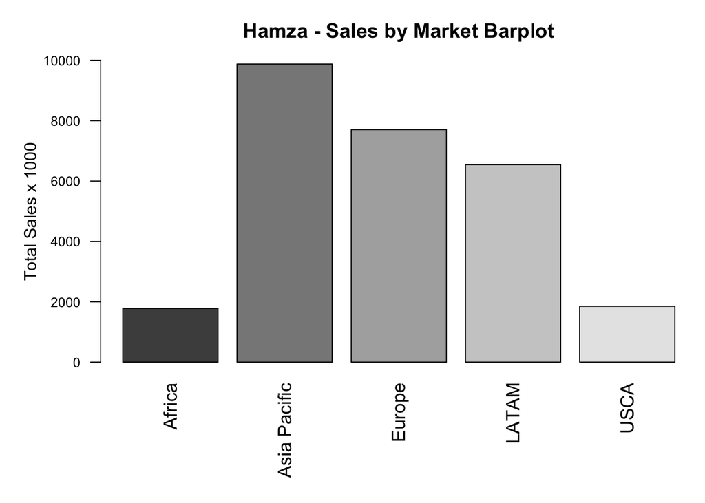

```r
par(mar = c(7,5,3,.4))

salesbar <- barplot(table8$Total_Market_Sales/1000,
         main = "Hamza - Sales by Market Barplot",
        names = c("Africa","Asia Pacific","Europe","LATAM","USCA"),
        col = gray.colors(5),
        ylab = "Total Sales x 1000",
        ylim = c(0,10000),
        las = 2,
        cex.axis = .8,
        cex.names = 1.1,
        space = 0.2)
```

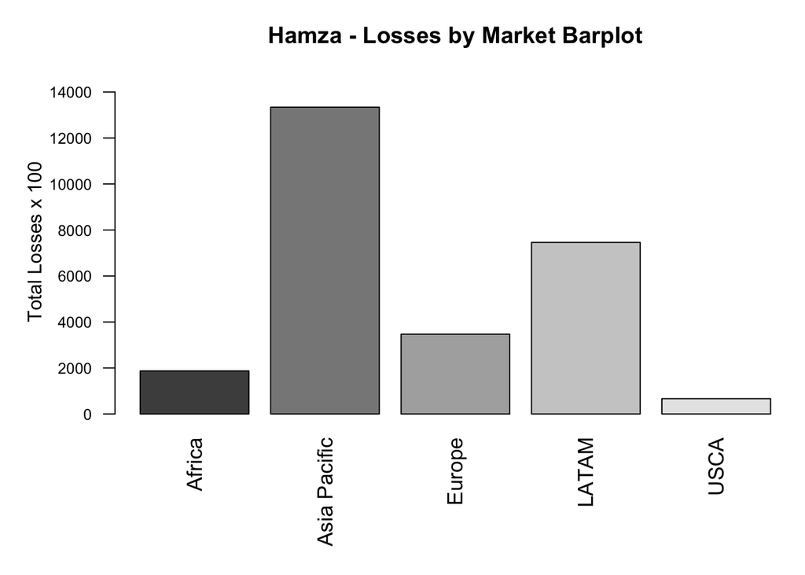

```r
lossesbar <- barplot(table8$Total_Market_Loss/100,
         main = "Hamza - Losses by Market Barplot",
        names = c("Africa","Asia Pacific","Europe","LATAM","USCA"),
        col = gray.colors(5),
        ylab = "Total Losses x 100",
        ylim = c(0,15000),
        las = 2,
        cex.axis = .8,
        cex.names = 1.1,
        space = 0.2)
```

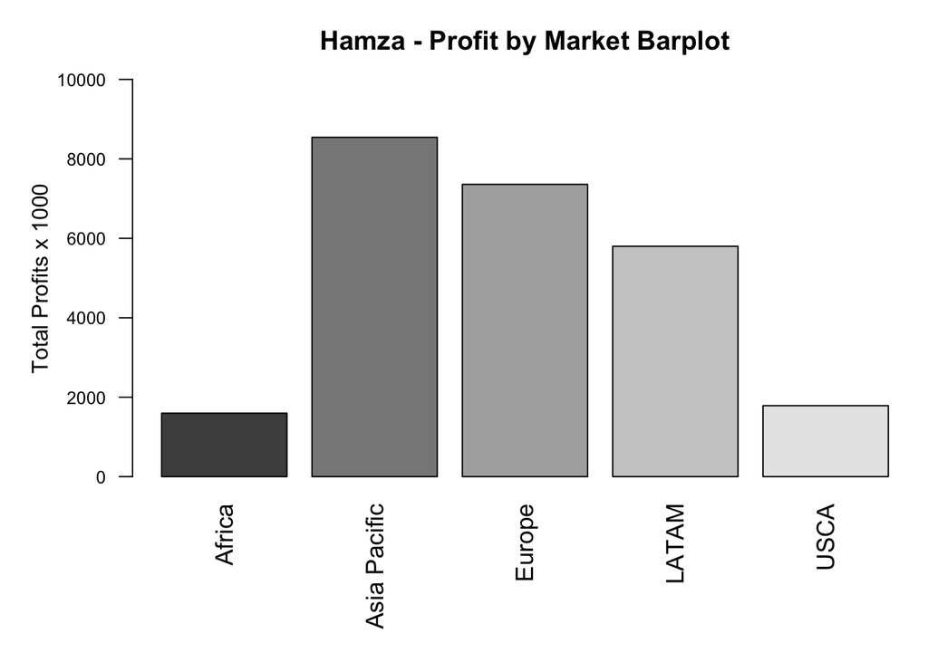

```r
profitbar <- barplot(table8$Total_Market_Profit/1000,
         main = "Hamza - Profit by Market Barplot",
        names = c("Africa","Asia Pacific","Europe","LATAM","USCA"),
        col = gray.colors(5),
        ylab = "Total Profits x 1000",
        ylim = c(0,10000),
        las = 2,
        cex.axis = .8,
        cex.names = 1.1,
        space = 0.2)
```

Bibliography

Chiluiza, D. (2021, June). Introduction to analytics using R, R Studio and R Markdown Short manual serie. RPubs. Retrieved February 5, 2023, from https://rpubs.com/Dee_Chiluiza/home

Zhu, H. (2021, February 19). Create Awesome HTML Table with knitr::kable and kableExtra. Create awesome HTML table with knitr::kable and kableextra. Retrieved February 18, 2023, from https://cran.r-project.org/web/packages/kableExtra/vignettes/awesome_table_in_html.html

Zhu, Y. F. and J. (2022, June 5). R programming: Zero to pro. 6.7 Grouped Mutate and Filter via group_by(). Retrieved February 18, 2023, from https://r02pro.github.io/grouped-mutate-filter.html